# Logistic Regression

Laurel Brehm

# Logistic regression: to a generalized line

So far we have examined the way that predictors (both continuous and categorical) affect a continuous, linear dependent measure.

But there’s more we can do.

The equations that implement linear regression have been generalized to other dependant measures to make *GLM*s – generalized linear models.

One case of special interest is logistic regression: predicting a dichotomous (binomial) outcome from continuous or categorical predictors.

# Probability and odds

How do we turn a binomial outcome into a continuous measure? Through thinking about probability and its sister, odds.

Probability = the number of times an event occurred, divided by all possible outcomes.

- $p$(Wednesday) = 1/7 (one in seven)
- Probability ranges from 0 to 1.

# Probability and odds

How do we turn a binomial outcome into a continuous measure? Through thinking about probability and its sister, odds.

Probability = the number of times an event occurred, divided by all possible outcomes.

- $p$(Wednesday) = 1/7 (one in seven)
- Probability ranges from 0 to 1.

Odds = the number of times an event occurred, divided by the other outcomes

- odds(Wednesday) = 1/6 (one to six)
- Odds ranges from 0 to infinity.

# Probability and odds

Probabilty goes from 0 to 1, odds goes from 0 to infinity

Neither of these is great for fitting a regression model… which requires an unbounded y variable.

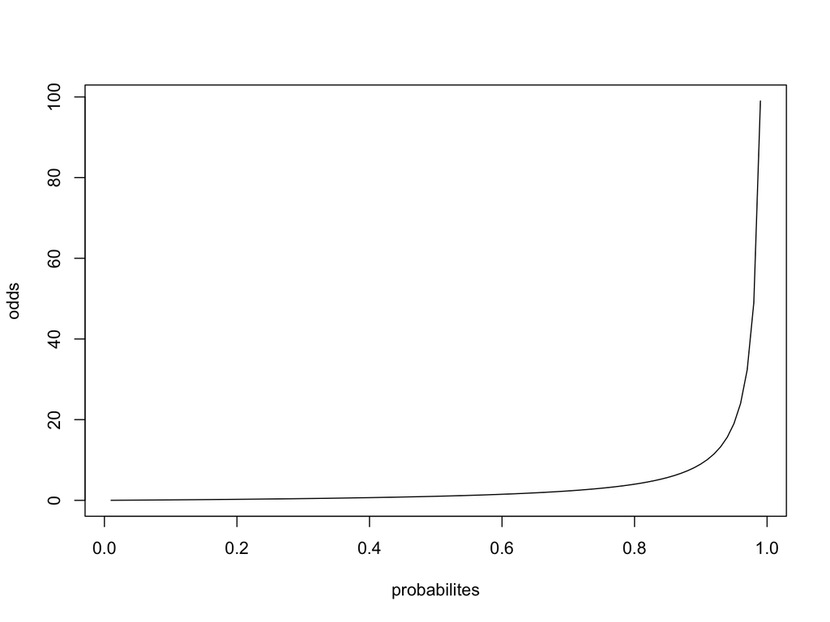

# Log odds

Log odds transforms odds to an unbounded scale (negative to positive infinity).

This means if we examine the log odds of a dependent measure, we can adapt the linear model.

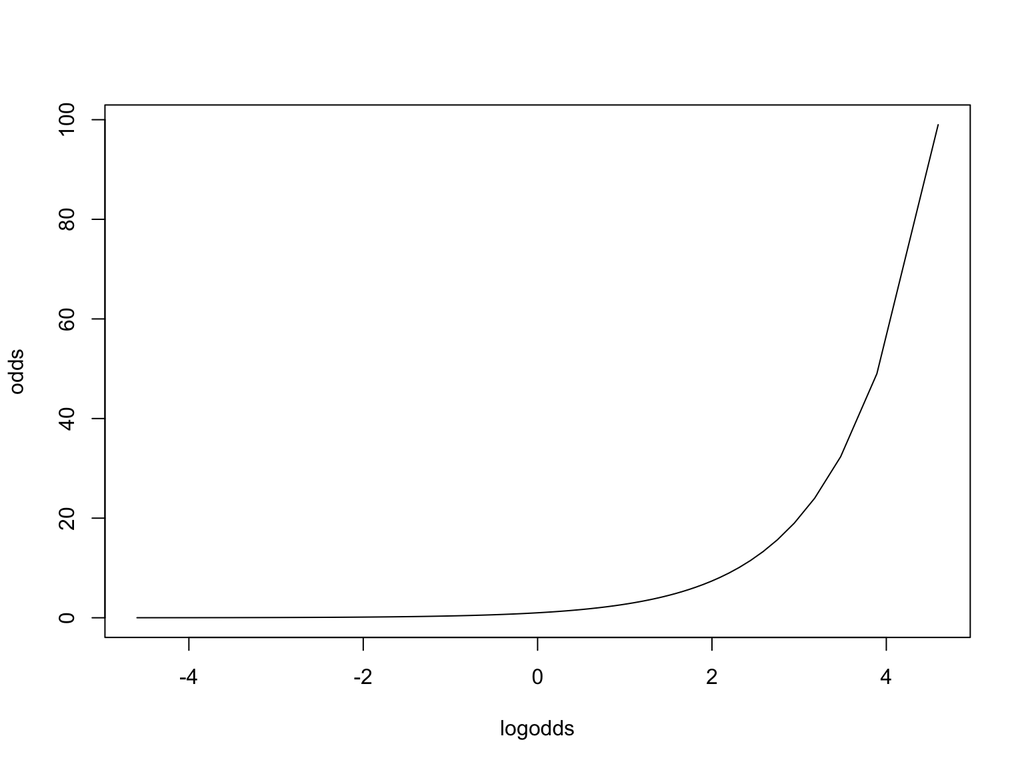

# What does logistic regression do?

Logistic regression essentially asks the question:

does one outcome $p$ occur more often than all other outcomes $1-p$, given my predictors?

It is implemented in this equation: $log(\frac{p}{1-p}) = \beta_0 + \beta_1$

# What does logistic regression do?

Logistic regression essentially asks the question:

does one outcome p occur more often than another, given my predictors?

It is implemented in this equation: $log(\frac{p}{1-p}) = \beta_0 + \beta_1$

The left side is the link function: log odds of outcome p.

The right side is our beta friends: intercept, and any predictors you have (slopes)

There are no residuals, because of the way the link function to y is operationalized (outcome p, or outcome 1-p)

# Visualizing effects

Logistic regression works in log-odds space. So often, you’ll see it visualized in terms of sigmoid curves like this:

Note that equal odds = 50% probabilty = log odds 0.

Note that the curve gets flat on the ends– this makes it mathematically challenging to detect differences when outcomes appear freqeuently, or almost never.

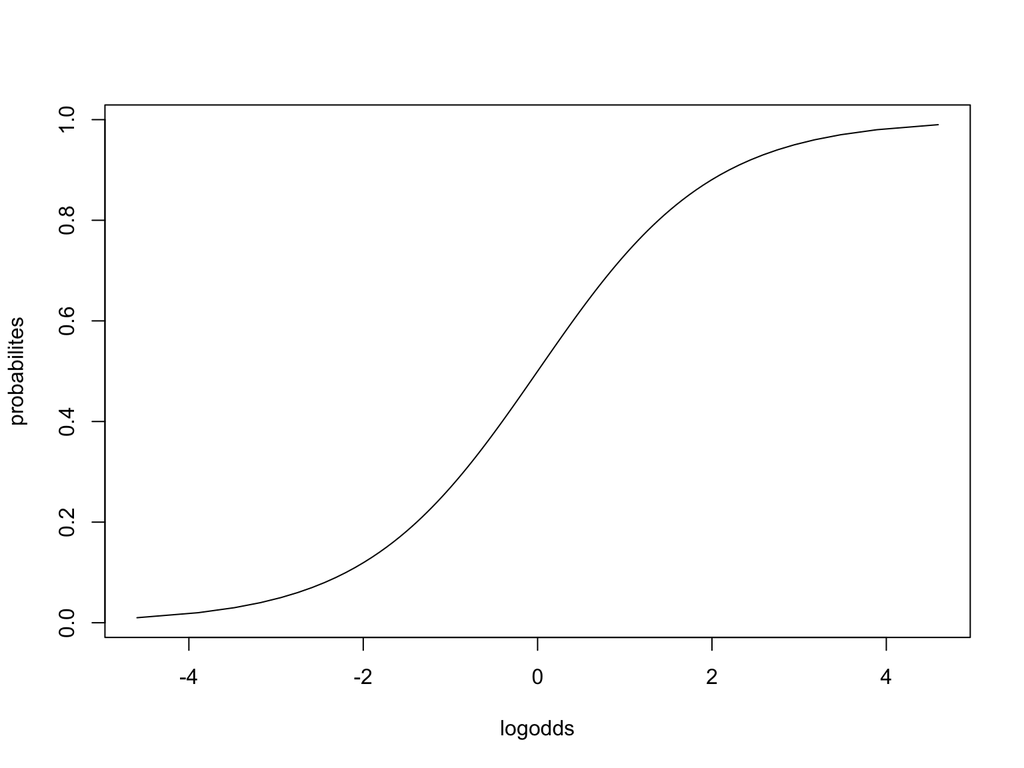

# Implementing logistic regression

It is very simple to implement a logistic regression model in R. It is somewhat less simple to understand what the model means.

We will walk through 2 examples today– one with no repeated measures in these slides, and one with repeated measures in the ‘tutorial’ code.

# Walk-through of an example: Titanic

We’ll start with a simple logistic regression example, that has no repeated measures in it: Titanic survivorship data.

People either survived (a success, coded as 1), or they did not. This is a binomial outcome.

Fortunately, this disaster also only happened once– so, again, no repeated measures.

Start by reading in the data, re-coding one variable appropriately, and creating a table that shows how many people survived.

```r
TitanicAll <- read.csv('TitanicAll.csv',header=T, sep="\t")

TitanicAll$Pclass <- as.factor(TitanicAll$Pclass)

TitanicAll %>% group_by(Survived) %>% summarise(n())
```

```
## # A tibble: 2 x 2
##   Survived `n()`
##      <int> <int>
## 1        0   424
## 2        1   290
```

As a whole, more failures than successes (surviving).

# Titanic model: Tabulating by age

One thing I’d heard about disaster scenarios is that people try to save children. I do hope this is the case. Let’s test it here in these data.

Tabulate survivorship by age, binning to units of 10. The mid-point of the bin is the integer value– (so, 0 reflects kids under 5, 10 reflects age 5-15, and so forth).

This shows that more people in the very youngest ages survived than died– that’s good to hear.

```r
TitanicAll %>% mutate(BinAge = round(Age/10)*10) %>% group_by(BinAge, Survived) %>% summarise(n())
```

```
## # A tibble: 16 x 3
## # Groups:   BinAge [9]
##    BinAge Survived `n()`
##     <dbl>    <int> <int>
##  1      0        0    13
##  2      0        1    31
##  3     10        0    20
##  4     10        1    14
##  5     20        0   144
##  6     20        1    79
##  7     30        0   106
##  8     30        1    72
##  9     40        0    76
## 10     40        1    56
## 11     50        0    36
## 12     50        1    25
## 13     60        0    22
## 14     60        1    12
## 15     70        0     7
## 16     80        1     1
```

# Titanic model: analysis

Next, we implement whether age predicts surviving in the model below.

Note that it is a *g*lm and that there is this additional thing at the end– family=‘binomial’

This is because there are lots of types of glm models– binomial is probably the most common one.

```r
glm1 <- glm(Survived ~ Age, data=TitanicAll, family='binomial')
```

# Titanic model: output

In this model output table, focus on the coefficients.

These are in log-odd space.

Think: What do the negative log odds mean, if log odds= zero means 50% probability ?

```r
summary(glm1)
```

```
##
## Call:
## glm(formula = Survived ~ Age, family = "binomial", data = TitanicAll)
##
## Deviance Residuals:
##     Min       1Q   Median       3Q      Max
## -1.1488  -1.0361  -0.9544   1.3159   1.5908
##
## Coefficients:
##             Estimate Std. Error z value Pr(>|z|)
## (Intercept) -0.05672    0.17358  -0.327   0.7438
## Age         -0.01096    0.00533  -2.057   0.0397 *
## ---
## Signif. codes:  0 '***' 0.001 '**' 0.01 '*' 0.05 '.' 0.1 ' ' 1
##
## (Dispersion parameter for binomial family taken to be 1)
##
##     Null deviance: 964.52  on 713  degrees of freedom
## Residual deviance: 960.23  on 712  degrees of freedom
## AIC: 964.23
##
## Number of Fisher Scoring iterations: 4
```

# Titanic model: Survivorship by age

For the intercept, this reflects that the likely outcome was not surviving.

For the main effect, this reflects that not surviving became more likely for older people.

```r
summary(glm1)
```

```
##
## Call:
## glm(formula = Survived ~ Age, family = "binomial", data = TitanicAll)
##
## Deviance Residuals:
##     Min       1Q   Median       3Q      Max
## -1.1488  -1.0361  -0.9544   1.3159   1.5908
##
## Coefficients:
##             Estimate Std. Error z value Pr(>|z|)
## (Intercept) -0.05672    0.17358  -0.327   0.7438
## Age         -0.01096    0.00533  -2.057   0.0397 *
## ---
## Signif. codes:  0 '***' 0.001 '**' 0.01 '*' 0.05 '.' 0.1 ' ' 1
##
## (Dispersion parameter for binomial family taken to be 1)
##
##     Null deviance: 964.52  on 713  degrees of freedom
## Residual deviance: 960.23  on 712  degrees of freedom
## AIC: 964.23
##
## Number of Fisher Scoring iterations: 4
```

# Titanic model: visualizing

Think: what does this plot mean?

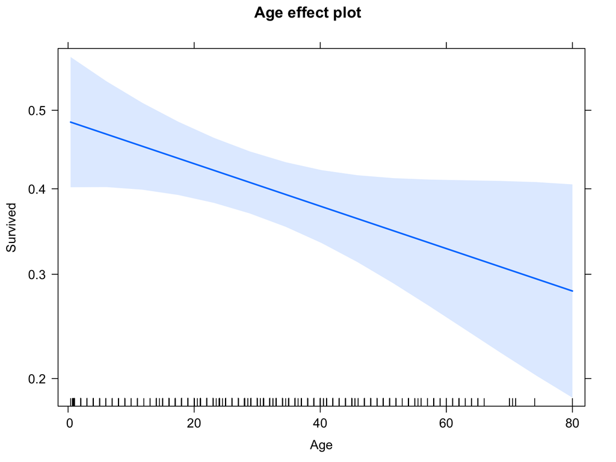

```r
plot(effect('Age',glm1))
```

# Titanic model: visualizing

About half of the very young survived, but about 30% of the very old survived. So this ‘children first’ scheme is a bit more complex– the effects are pretty small.

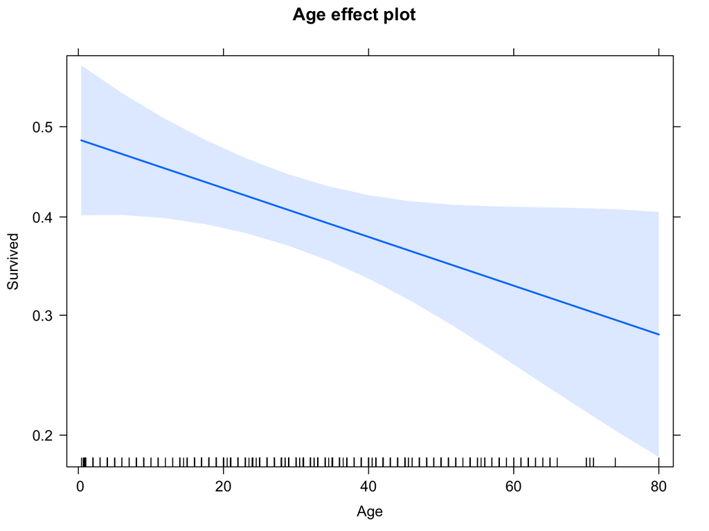

```r
plot(effect('Age',glm1))
```

# Titanic model: visualizing

We can make a ggplot that adds the actual outcome to the fitted line.

Note that while the model predicts the odds of success (here transformed to probability), the actual data are 1 and 0.

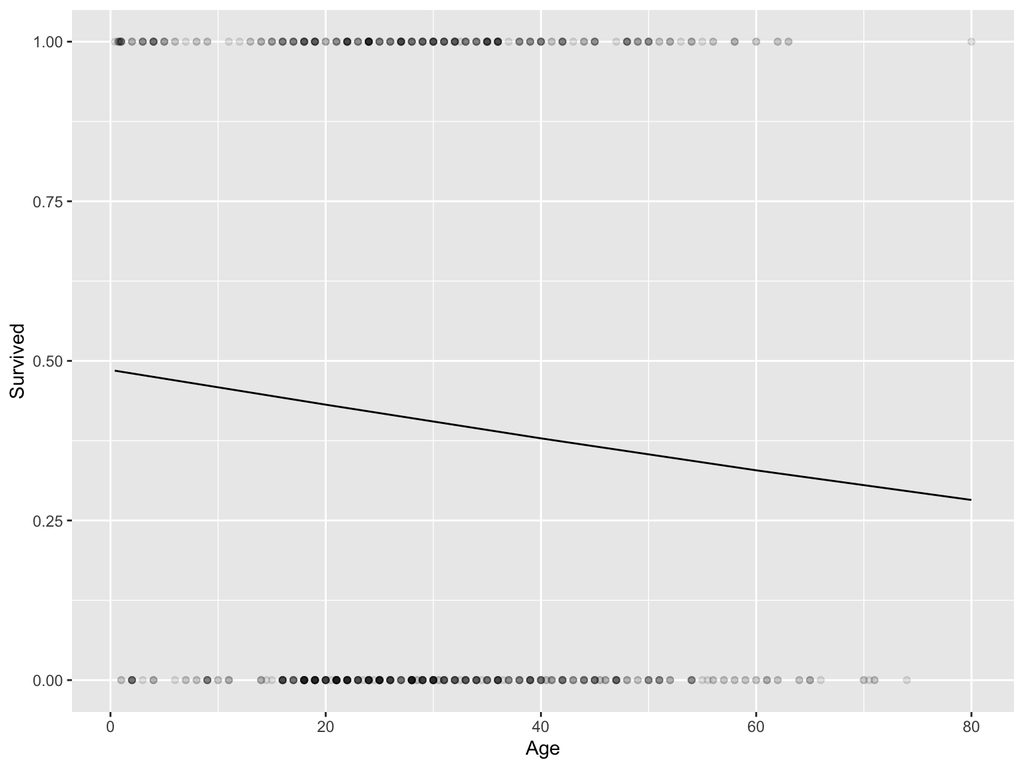

```r
mci <- as.data.frame(effect("Age",glm1))

ggplot(data=TitanicAll,aes(x=Age,y=Survived))+
  geom_point(alpha=.1)+
  geom_line(data=mci,aes(y=fit))
```